# Activity Monitoring Dataset

### Data consists of number of steps recorded at 5 min interval for a 2 month period

```r
setwd("C:\\Users\\Hasan\\Statistics\\R\\rep data activity")
data=read.csv("activity.csv")
data$date=as.Date(data$date)
head(data)
```

```
##   steps       date interval
## 1    NA 2012-10-01        0
## 2    NA 2012-10-01        5
## 3    NA 2012-10-01       10
## 4    NA 2012-10-01       15
## 5    NA 2012-10-01       20
## 6    NA 2012-10-01       25
```

**Calculting the total number of steps taken each day**

```r
library(dplyr)
sum.day=data %>%
  group_by(date) %>%
                summarise(sum=sum(steps,na.rm=TRUE))
head(sum.day)
```

```
## # A tibble: 6 x 2
##   date         sum
##   <date>     <int>
## 1 2012-10-01     0
## 2 2012-10-02   126
## 3 2012-10-03 11352
## 4 2012-10-04 12116
## 5 2012-10-05 13294
## 6 2012-10-06 15420
```

**Histogram of the total number of steps taken each day**

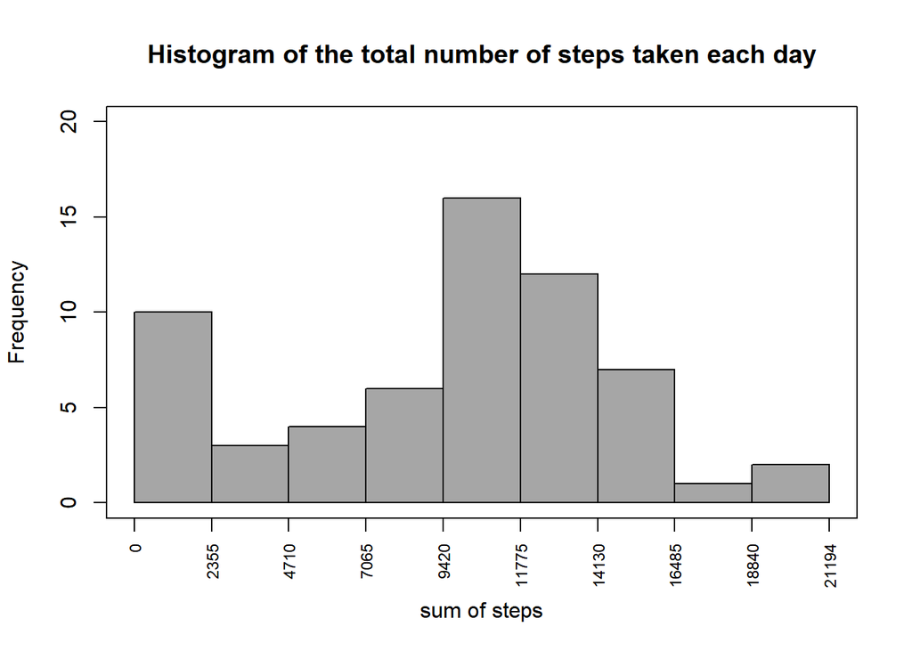

```r
breaks=with(sum.day,seq(min(sum),max(sum),length=10))
with(sum.day,hist(sum,breaks=breaks,xaxt="n",ylim=c(0,20),xlab="sum of steps",
     main="Histogram of the total number of steps taken each day",col=rgb(0,0,0,0.35)))
axis(1,at=breaks,labels=ceiling(breaks),las=2,cex.axis=0.75)
box()
```

```r
mean.day=mean(sum.day$sum)
print(mean.day)
```

```
## [1] 9354.23
```

```r
median.day=median(sum.day$sum)
print(median.day)
```

```
## [1] 10395
```

**Calculting the average number of steps taken in each interval in 2 months**

```r
sum.int=data %>%
  group_by(interval) %>%
  summarise(mean=mean(steps,na.rm=TRUE))
head(sum.int)
```

```
## # A tibble: 6 x 2
##   interval   mean
##      <int>  <dbl>
## 1        0 1.72
## 2        5 0.340
## 3       10 0.132
## 4       15 0.151
## 5       20 0.0755
## 6       25 2.09
```

**Time series plot of the average number of steps taken in each interval**

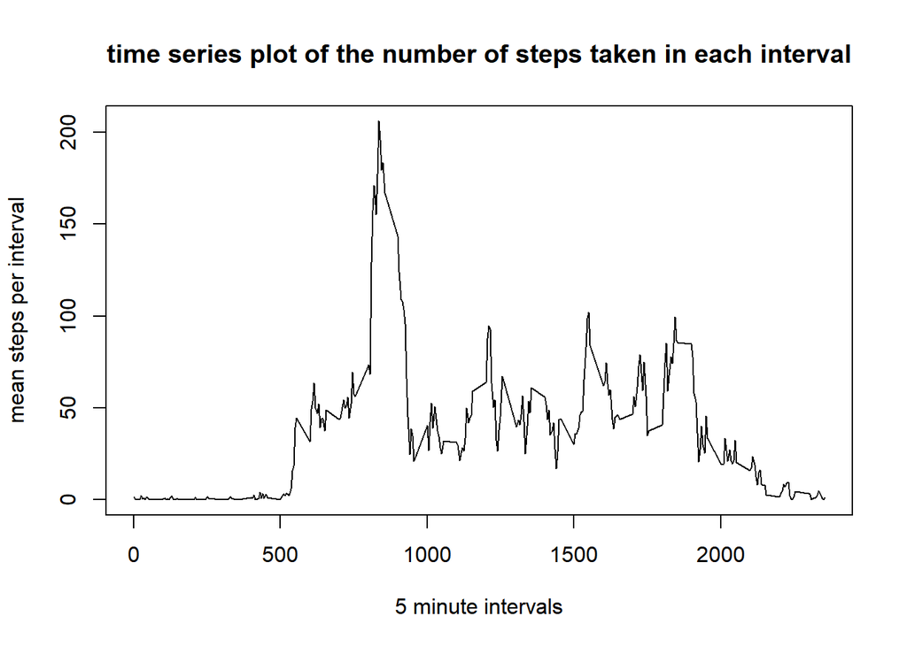

```r
with(sum.int,plot(interval,mean,type="l",
                  xlab="5 minute intervals",ylab="mean steps per interval",
                  main="time series plot of the number of steps taken in each interval"))
```

**The 5 min interval having the maximum number of steps on an average**

```r
sum.int[which.max(sum.int$mean),"interval"]
```

```
## # A tibble: 1 x 1
##   interval
##      <int>
## 1      835
```

**Imputation** The impuation of missing values is carried out by taking a random sample from the available data and putting them in place of the missing values This incorporates a randomness in the data and provies greated precision

```r
num.na=sum(is.na(data$steps))
pos.na=which(is.na(data$steps))
impute=sample(data$steps[-pos.na],num.na)
data.imp=data
data.imp[pos.na,"steps"]=impute
head(data.imp)
```

```
##   steps       date interval
## 1     0 2012-10-01        0
## 2     0 2012-10-01        5
## 3    79 2012-10-01       10
## 4     0 2012-10-01       15
## 5     0 2012-10-01       20
## 6     0 2012-10-01       25
```

**Calculating the total number of steps taken each day after imputation**

```r
sum.day.imp=data.imp %>%
  group_by(date) %>%
  summarise(sum=sum(steps,na.rm=TRUE))
head(sum.day.imp)
```

```
## # A tibble: 6 x 2
##   date         sum
##   <date>     <int>
## 1 2012-10-01  5775
## 2 2012-10-02   126
## 3 2012-10-03 11352
## 4 2012-10-04 12116
## 5 2012-10-05 13294
## 6 2012-10-06 15420
```

**Histogram of total number of steps taken each day before and after imputation**

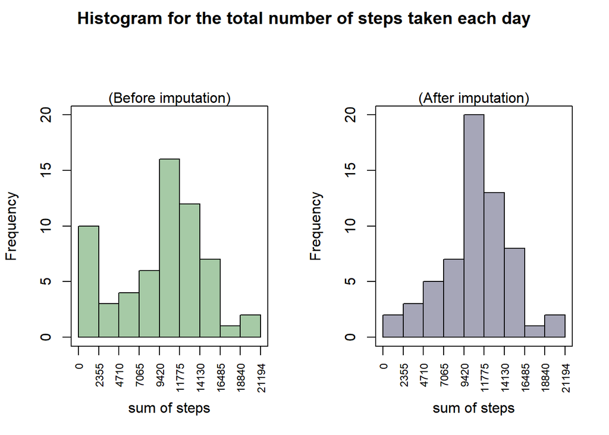

```r
par(mfrow=c(1,2),oma=c(0,0,2,0))
breaks=with(sum.day,seq(min(sum),max(sum),length=10))

with(sum.day,hist(sum,breaks=breaks,freq=TRUE,xaxt="n",ylim=c(0,20),xlab="sum of steps",
                  main="",col=rgb(0,0.4,0,0.35)))
axis(1,at=breaks,labels=ceiling(breaks),las=2,cex.axis=0.75)
mtext("(Before imputation)",side=3)
box()

with(sum.day.imp,hist(sum,breaks=breaks,freq=TRUE,xaxt="n",ylim=c(0,20),xlab="sum of steps",
                  main="",col=rgb(0,0,0.2,0.35)))
axis(1,at=breaks,labels=ceiling(breaks),las=2,cex.axis=0.75)
mtext("(After imputation)",side=3)
box()
title(main="Histogram for the total number of steps taken each day",outer=TRUE)
```

```r
name=list(c("mean","median"),c("before imputation","after imputation"))
mean.day.imp=mean(sum.day.imp$sum)
median.day.imp=median(sum.day.imp$sum)
matrix(c(mean.day,median.day,mean.day.imp,median.day.imp),2,2,dimnames=name)
```

```
##        before imputation after imputation
## mean             9354.23         10738.92
## median          10395.00         10948.00
```

```r
data.imp$day=weekdays(data.imp$date,abbreviate=TRUE)

pos=with(data.imp,which(day=="Fri" | day=="Sat" | day=="Sun"))
data.imp$weekfact="weekday"
data.imp$weekfact[pos]="weekend"

sum.week=data.imp %>%
  group_by(weekfact,interval) %>%
  summarise(mean=mean(steps))
```

**Panel plot to compare the avg number of steps taken in each interval over weekday and weekend***

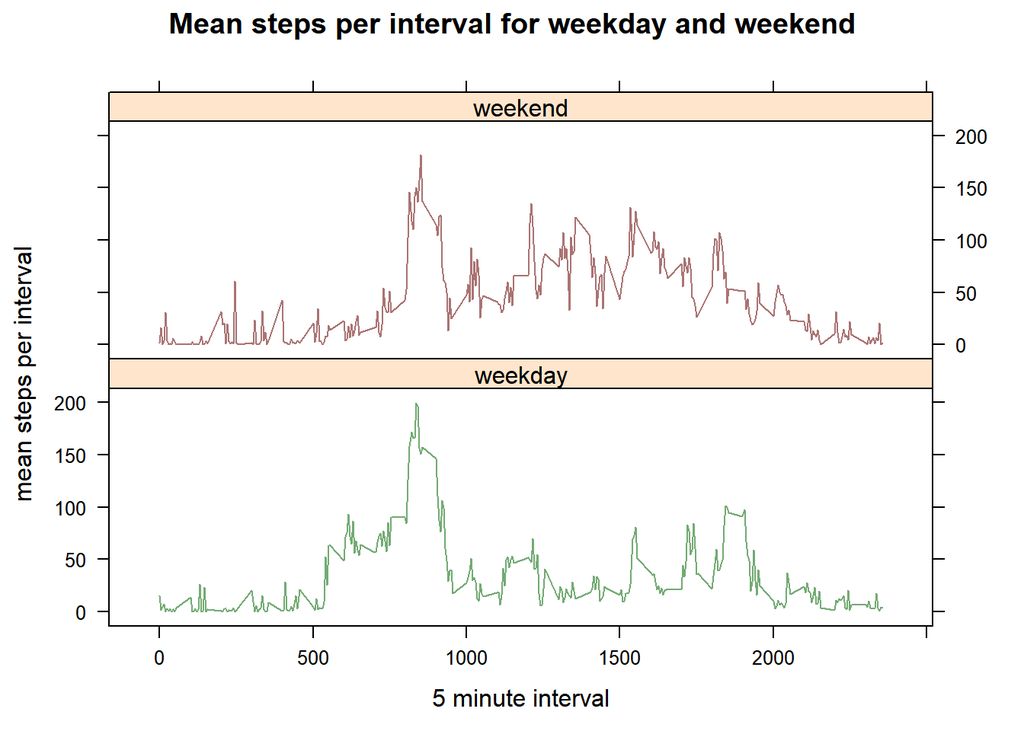

```r
library(lattice)
color=c(rgb(0,0.4,0,0.55),rgb(0.4,0,0,0.55))
xyplot(mean~interval | weekfact,data=sum.week,type="l",
       col=color,groups=weekfact,layout=c(1,2),
       xlab="5 minute interval",ylab="mean steps per interval",
       main="Mean steps per interval for weekday and weekend")
```